# Risk Factor Analysis

## Outcome Variable

**Outcome Variable:** ever_stunted

## Predictor Variables

**Intervention Variable:** fage

**Adjustment Set:**

- arm
- W_mage
- meducyrs
- feducyrs
- W_mhtcm
- W_mwtkg
- W_mbmi
- W_fhtcm
- single
- brthmon
- delta_W_mage
- delta_meducyrs
- delta_feducyrs
- delta_W_mhtcm
- delta_W_mwtkg
- delta_W_mbmi
- delta_W_fhtcm
- delta_single
- delta_brthmon

## Stratifying Variables

The analysis was stratified on these variable(s):

- agecat
- studyid
- country

## Data Summary

| agecat | studyid | country | fage | ever_stunted | n_cell | n |
| --- | --- | --- | --- | --- | --- | --- |
| 0-24 months | COHORTS | GUATEMALA | >=38 | 0 | 96 | 1301 |
| 0-24 months | COHORTS | GUATEMALA | >=38 | 1 | 290 | 1301 |
| 0-24 months | COHORTS | GUATEMALA | <32 | 0 | 147 | 1301 |
| 0-24 months | COHORTS | GUATEMALA | <32 | 1 | 462 | 1301 |
| 0-24 months | COHORTS | GUATEMALA | [32-38) | 0 | 64 | 1301 |
| 0-24 months | COHORTS | GUATEMALA | [32-38) | 1 | 242 | 1301 |
| 0-24 months | COHORTS | PHILIPPINES | >=38 | 0 | 90 | 2951 |
| 0-24 months | COHORTS | PHILIPPINES | >=38 | 1 | 240 | 2951 |
| 0-24 months | COHORTS | PHILIPPINES | <32 | 0 | 669 | 2951 |
| 0-24 months | COHORTS | PHILIPPINES | <32 | 1 | 1414 | 2951 |
| 0-24 months | COHORTS | PHILIPPINES | [32-38) | 0 | 157 | 2951 |
| 0-24 months | COHORTS | PHILIPPINES | [32-38) | 1 | 381 | 2951 |
| 0-24 months | LCNI-5 | MALAWI | >=38 | 0 | 10 | 106 |
| 0-24 months | LCNI-5 | MALAWI | >=38 | 1 | 16 | 106 |
| 0-24 months | LCNI-5 | MALAWI | <32 | 0 | 22 | 106 |
| 0-24 months | LCNI-5 | MALAWI | <32 | 1 | 34 | 106 |
| 0-24 months | LCNI-5 | MALAWI | [32-38) | 0 | 8 | 106 |
| 0-24 months | LCNI-5 | MALAWI | [32-38) | 1 | 16 | 106 |
| 0-24 months | MAL-ED | BANGLADESH | >=38 | 0 | 27 | 151 |
| 0-24 months | MAL-ED | BANGLADESH | >=38 | 1 | 42 | 151 |
| 0-24 months | MAL-ED | BANGLADESH | <32 | 0 | 7 | 151 |
| 0-24 months | MAL-ED | BANGLADESH | <32 | 1 | 23 | 151 |
| 0-24 months | MAL-ED | BANGLADESH | [32-38) | 0 | 23 | 151 |
| 0-24 months | MAL-ED | BANGLADESH | [32-38) | 1 | 29 | 151 |
| 0-24 months | MAL-ED | BRAZIL | >=38 | 0 | 21 | 79 |
| 0-24 months | MAL-ED | BRAZIL | >=38 | 1 | 9 | 79 |
| 0-24 months | MAL-ED | BRAZIL | <32 | 0 | 8 | 79 |
| 0-24 months | MAL-ED | BRAZIL | <32 | 1 | 10 | 79 |
| 0-24 months | MAL-ED | BRAZIL | [32-38) | 0 | 25 | 79 |
| 0-24 months | MAL-ED | BRAZIL | [32-38) | 1 | 6 | 79 |

[output cut: 204 more lines]

The following strata were considered:

- agecat: 0-24 months, studyid: COHORTS, country: GUATEMALA
- agecat: 0-24 months, studyid: COHORTS, country: PHILIPPINES
- agecat: 0-24 months, studyid: LCNI-5, country: MALAWI
- agecat: 0-24 months, studyid: MAL-ED, country: BANGLADESH
- agecat: 0-24 months, studyid: MAL-ED, country: BRAZIL
- agecat: 0-24 months, studyid: MAL-ED, country: INDIA
- agecat: 0-24 months, studyid: MAL-ED, country: NEPAL
- agecat: 0-24 months, studyid: MAL-ED, country: PERU
- agecat: 0-24 months, studyid: MAL-ED, country: SOUTH AFRICA
- agecat: 0-24 months, studyid: MAL-ED, country: TANZANIA, UNITED REPUBLIC OF
- agecat: 0-24 months, studyid: PROBIT, country: BELARUS
- agecat: 0-24 months, studyid: SAS-CompFeed, country: INDIA
- agecat: 0-24 months, studyid: SAS-FoodSuppl, country: INDIA
- agecat: 0-6 months, studyid: COHORTS, country: GUATEMALA
- agecat: 0-6 months, studyid: COHORTS, country: PHILIPPINES
- agecat: 0-6 months, studyid: LCNI-5, country: MALAWI
- agecat: 0-6 months, studyid: MAL-ED, country: BANGLADESH
- agecat: 0-6 months, studyid: MAL-ED, country: BRAZIL
- agecat: 0-6 months, studyid: MAL-ED, country: INDIA
- agecat: 0-6 months, studyid: MAL-ED, country: NEPAL
- agecat: 0-6 months, studyid: MAL-ED, country: PERU
- agecat: 0-6 months, studyid: MAL-ED, country: SOUTH AFRICA
- agecat: 0-6 months, studyid: MAL-ED, country: TANZANIA, UNITED REPUBLIC OF
- agecat: 0-6 months, studyid: PROBIT, country: BELARUS
- agecat: 0-6 months, studyid: SAS-CompFeed, country: INDIA
- agecat: 0-6 months, studyid: SAS-FoodSuppl, country: INDIA
- agecat: 6-24 months, studyid: COHORTS, country: GUATEMALA
- agecat: 6-24 months, studyid: COHORTS, country: PHILIPPINES
- agecat: 6-24 months, studyid: LCNI-5, country: MALAWI
- agecat: 6-24 months, studyid: MAL-ED, country: BANGLADESH
- agecat: 6-24 months, studyid: MAL-ED, country: BRAZIL
- agecat: 6-24 months, studyid: MAL-ED, country: INDIA
- agecat: 6-24 months, studyid: MAL-ED, country: NEPAL
- agecat: 6-24 months, studyid: MAL-ED, country: PERU
- agecat: 6-24 months, studyid: MAL-ED, country: SOUTH AFRICA
- agecat: 6-24 months, studyid: MAL-ED, country: TANZANIA, UNITED REPUBLIC OF
- agecat: 6-24 months, studyid: PROBIT, country: BELARUS
- agecat: 6-24 months, studyid: SAS-CompFeed, country: INDIA
- agecat: 6-24 months, studyid: SAS-FoodSuppl, country: INDIA

### Dropped Strata

Some strata were dropped due to rare outcomes:

- agecat: 0-24 months, studyid: MAL-ED, country: SOUTH AFRICA
- agecat: 0-24 months, studyid: MAL-ED, country: TANZANIA, UNITED REPUBLIC OF
- agecat: 0-6 months, studyid: LCNI-5, country: MALAWI
- agecat: 0-6 months, studyid: MAL-ED, country: NEPAL
- agecat: 0-6 months, studyid: MAL-ED, country: SOUTH AFRICA
- agecat: 6-24 months, studyid: MAL-ED, country: BRAZIL
- agecat: 6-24 months, studyid: MAL-ED, country: NEPAL
- agecat: 6-24 months, studyid: MAL-ED, country: PERU
- agecat: 6-24 months, studyid: MAL-ED, country: SOUTH AFRICA
- agecat: 6-24 months, studyid: MAL-ED, country: TANZANIA, UNITED REPUBLIC OF

## Methods Detail

We’re interested in the causal parameters $E[Y_a]$ for all values of $a \in \mathcal{A}$. These parameters represent the mean outcome if, possibly contrary to fact, we intervened to set all units to have $A=a$. Under the randomization and positivity assumptions, these are identified by the statistical parameters $\psi_a=E_W[E_{Y|A,W}(Y|A=a,W)]$. In addition, we’re interested in the mean of $Y$, $E[Y]$ under no intervention (the observed mean). We will estimate these parameters by using SuperLearner to fit the relevant likelihood factors – $E_{Y|A,W}(Y|A=a,W)$ and $p(A=a|W)$, and then updating our likelihood fit using a joint TMLE.

For unadjusted analyses ($W=\{\}$), initial likelihoods were estimated using Lrnr_glm to estimate the simple $E(Y|A)$ and Lrnr_mean to estimate $p(A)$. For adjusted analyses, a small library containing Lrnr_glmnet, Lrnr_xgboost, and Lrnr_mean was used.

Having estimated these parameters, we will then use the delta method to estimate relative risks and attributable risks relative to a prespecified baseline level of $A$.

# Results Detail

## Results Plots

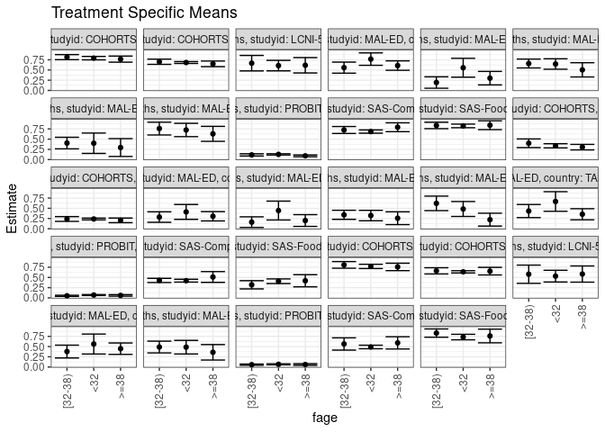

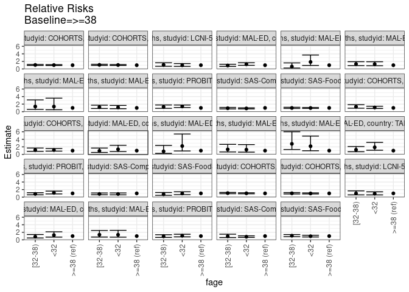

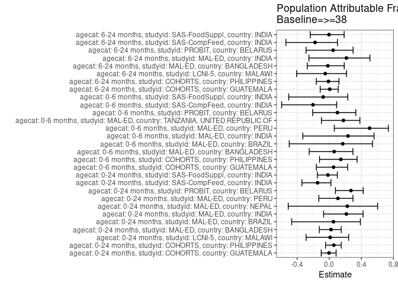

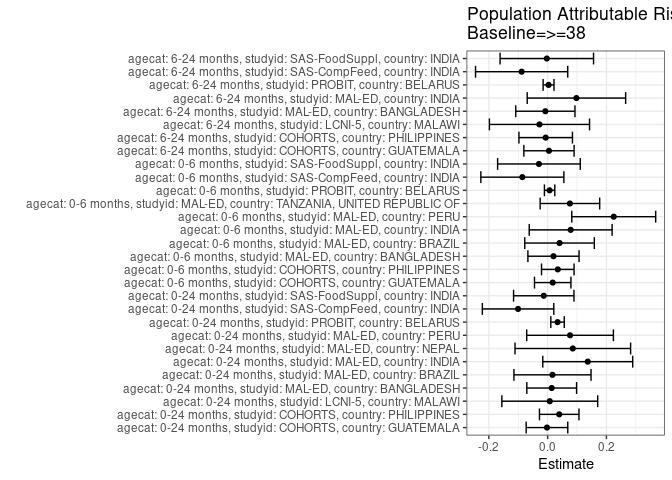

## Results Table

### Parameter: TSM

| agecat | studyid | country | intervention_level | baseline_level | estimate | ci_lower | ci_upper |
| --- | --- | --- | --- | --- | --- | --- | --- |
| 0-24 months | COHORTS | GUATEMALA | >=38 | NA | 0.7662867 | 0.6917460 | 0.8408273 |
| 0-24 months | COHORTS | GUATEMALA | <32 | NA | 0.7905895 | 0.7487025 | 0.8324765 |
| 0-24 months | COHORTS | GUATEMALA | [32-38) | NA | 0.8146002 | 0.7526047 | 0.8765957 |
| 0-24 months | COHORTS | PHILIPPINES | >=38 | NA | 0.6502114 | 0.5815106 | 0.7189122 |
| 0-24 months | COHORTS | PHILIPPINES | <32 | NA | 0.6826766 | 0.6597977 | 0.7055555 |
| 0-24 months | COHORTS | PHILIPPINES | [32-38) | NA | 0.7020540 | 0.6378705 | 0.7662376 |
| 0-24 months | LCNI-5 | MALAWI | >=38 | NA | 0.6153846 | 0.4274935 | 0.8032758 |
| 0-24 months | LCNI-5 | MALAWI | <32 | NA | 0.6071429 | 0.4786216 | 0.7356642 |
| 0-24 months | LCNI-5 | MALAWI | [32-38) | NA | 0.6666667 | 0.4771731 | 0.8561602 |
| 0-24 months | MAL-ED | BANGLADESH | >=38 | NA | 0.6086957 | 0.4931579 | 0.7242334 |
| 0-24 months | MAL-ED | BANGLADESH | <32 | NA | 0.7666667 | 0.6148142 | 0.9185192 |
| 0-24 months | MAL-ED | BANGLADESH | [32-38) | NA | 0.5576923 | 0.4222517 | 0.6931329 |
| 0-24 months | MAL-ED | BRAZIL | >=38 | NA | 0.3000000 | 0.1349698 | 0.4650302 |
| 0-24 months | MAL-ED | BRAZIL | <32 | NA | 0.5555556 | 0.3245350 | 0.7865761 |
| 0-24 months | MAL-ED | BRAZIL | [32-38) | NA | 0.1935484 | 0.0535840 | 0.3335127 |
| 0-24 months | MAL-ED | INDIA | >=38 | NA | 0.5033127 | 0.3292729 | 0.6773525 |
| 0-24 months | MAL-ED | INDIA | <32 | NA | 0.6469352 | 0.5193753 | 0.7744951 |
| 0-24 months | MAL-ED | INDIA | [32-38) | NA | 0.6587018 | 0.5503160 | 0.7670877 |
| 0-24 months | MAL-ED | NEPAL | >=38 | NA | 0.2941176 | 0.0761377 | 0.5120976 |
| 0-24 months | MAL-ED | NEPAL | <32 | NA | 0.4000000 | 0.1504978 | 0.6495022 |
| 0-24 months | MAL-ED | NEPAL | [32-38) | NA | 0.4042553 | 0.2630590 | 0.5454516 |
| 0-24 months | MAL-ED | PERU | >=38 | NA | 0.6296296 | 0.4463996 | 0.8128597 |
| 0-24 months | MAL-ED | PERU | <32 | NA | 0.7241379 | 0.5605032 | 0.8877727 |
| 0-24 months | MAL-ED | PERU | [32-38) | NA | 0.7586207 | 0.6019523 | 0.9152890 |
| 0-24 months | PROBIT | BELARUS | >=38 | NA | 0.0909984 | 0.0697530 | 0.1122438 |
| 0-24 months | PROBIT | BELARUS | <32 | NA | 0.1270894 | 0.1116477 | 0.1425312 |
| 0-24 months | PROBIT | BELARUS | [32-38) | NA | 0.1144294 | 0.0870801 | 0.1417787 |
| 0-24 months | SAS-CompFeed | INDIA | >=38 | NA | 0.7914317 | 0.6823930 | 0.9004703 |
| 0-24 months | SAS-CompFeed | INDIA | <32 | NA | 0.6855379 | 0.6454157 | 0.7256602 |
| 0-24 months | SAS-CompFeed | INDIA | [32-38) | NA | 0.7241549 | 0.6389630 | 0.8093468 |

[output cut: 57 more lines]

### Parameter: E(Y)

| agecat | studyid | country | intervention_level | baseline_level | estimate | ci_lower | ci_upper |
| --- | --- | --- | --- | --- | --- | --- | --- |
| 0-24 months | COHORTS | GUATEMALA | NA | NA | 0.7640277 | 0.7409463 | 0.7871090 |
| 0-24 months | COHORTS | PHILIPPINES | NA | NA | 0.6895967 | 0.6729013 | 0.7062922 |
| 0-24 months | LCNI-5 | MALAWI | NA | NA | 0.6226415 | 0.5299266 | 0.7153564 |
| 0-24 months | MAL-ED | BANGLADESH | NA | NA | 0.6225166 | 0.5449406 | 0.7000925 |
| 0-24 months | MAL-ED | BRAZIL | NA | NA | 0.3164557 | 0.2132412 | 0.4196702 |
| 0-24 months | MAL-ED | INDIA | NA | NA | 0.6397516 | 0.5653649 | 0.7141382 |
| 0-24 months | MAL-ED | NEPAL | NA | NA | 0.3797468 | 0.2720427 | 0.4874510 |
| 0-24 months | MAL-ED | PERU | NA | NA | 0.7058824 | 0.6084428 | 0.8033219 |
| 0-24 months | PROBIT | BELARUS | NA | NA | 0.1247159 | 0.1092273 | 0.1402044 |
| 0-24 months | SAS-CompFeed | INDIA | NA | NA | 0.6908497 | 0.6505448 | 0.7311545 |
| 0-24 months | SAS-FoodSuppl | INDIA | NA | NA | 0.8277512 | 0.7915095 | 0.8639929 |
| 0-6 months | COHORTS | GUATEMALA | NA | NA | 0.3212928 | 0.2930610 | 0.3495246 |
| 0-6 months | COHORTS | PHILIPPINES | NA | NA | 0.2392409 | 0.2238460 | 0.2546359 |
| 0-6 months | MAL-ED | BANGLADESH | NA | NA | 0.3245033 | 0.2495788 | 0.3994278 |
| 0-6 months | MAL-ED | BRAZIL | NA | NA | 0.2405063 | 0.1456588 | 0.3353539 |
| 0-6 months | MAL-ED | INDIA | NA | NA | 0.3354037 | 0.2622476 | 0.4085599 |
| 0-6 months | MAL-ED | PERU | NA | NA | 0.4470588 | 0.3407351 | 0.5533826 |
| 0-6 months | MAL-ED | TANZANIA, UNITED REPUBLIC OF | NA | NA | 0.4300000 | 0.3324781 | 0.5275219 |
| 0-6 months | PROBIT | BELARUS | NA | NA | 0.0661259 | 0.0556767 | 0.0765750 |
| 0-6 months | SAS-CompFeed | INDIA | NA | NA | 0.4250164 | 0.3969651 | 0.4530677 |
| 0-6 months | SAS-FoodSuppl | INDIA | NA | NA | 0.3894231 | 0.3425088 | 0.4363374 |
| 6-24 months | COHORTS | GUATEMALA | NA | NA | 0.7619048 | 0.7334389 | 0.7903706 |
| 6-24 months | COHORTS | PHILIPPINES | NA | NA | 0.6470302 | 0.6263581 | 0.6677023 |
| 6-24 months | LCNI-5 | MALAWI | NA | NA | 0.5555556 | 0.4523209 | 0.6587902 |
| 6-24 months | MAL-ED | BANGLADESH | NA | NA | 0.4411765 | 0.3443418 | 0.5380111 |
| 6-24 months | MAL-ED | INDIA | NA | NA | 0.4579439 | 0.3630970 | 0.5527909 |
| 6-24 months | PROBIT | BELARUS | NA | NA | 0.0638554 | 0.0521938 | 0.0755170 |
| 6-24 months | SAS-CompFeed | INDIA | NA | NA | 0.5024631 | 0.4586872 | 0.5462389 |
| 6-24 months | SAS-FoodSuppl | INDIA | NA | NA | 0.7572016 | 0.7031798 | 0.8112234 |

### Parameter: RR

| agecat | studyid | country | intervention_level | baseline_level | estimate | ci_lower | ci_upper |
| --- | --- | --- | --- | --- | --- | --- | --- |
| 0-24 months | COHORTS | GUATEMALA | >=38 | >=38 | 1.0000000 | 1.0000000 | 1.000000 |
| 0-24 months | COHORTS | GUATEMALA | <32 | >=38 | 1.0317150 | 0.9239579 | 1.152039 |
| 0-24 months | COHORTS | GUATEMALA | [32-38) | >=38 | 1.0630488 | 0.9397825 | 1.202483 |
| 0-24 months | COHORTS | PHILIPPINES | >=38 | >=38 | 1.0000000 | 1.0000000 | 1.000000 |
| 0-24 months | COHORTS | PHILIPPINES | <32 | >=38 | 1.0499301 | 0.9402854 | 1.172360 |
| 0-24 months | COHORTS | PHILIPPINES | [32-38) | >=38 | 1.0797319 | 0.9394358 | 1.240980 |
| 0-24 months | LCNI-5 | MALAWI | >=38 | >=38 | 1.0000000 | 1.0000000 | 1.000000 |
| 0-24 months | LCNI-5 | MALAWI | <32 | >=38 | 0.9866071 | 0.6804443 | 1.430527 |
| 0-24 months | LCNI-5 | MALAWI | [32-38) | >=38 | 1.0833333 | 0.7138317 | 1.644101 |
| 0-24 months | MAL-ED | BANGLADESH | >=38 | >=38 | 1.0000000 | 1.0000000 | 1.000000 |
| 0-24 months | MAL-ED | BANGLADESH | <32 | >=38 | 1.2595238 | 0.9573355 | 1.657099 |
| 0-24 months | MAL-ED | BANGLADESH | [32-38) | >=38 | 0.9162088 | 0.6731774 | 1.246980 |
| 0-24 months | MAL-ED | BRAZIL | >=38 | >=38 | 1.0000000 | 1.0000000 | 1.000000 |
| 0-24 months | MAL-ED | BRAZIL | <32 | >=38 | 1.8518519 | 0.9292277 | 3.690543 |
| 0-24 months | MAL-ED | BRAZIL | [32-38) | >=38 | 0.6451613 | 0.2600567 | 1.600548 |
| 0-24 months | MAL-ED | INDIA | >=38 | >=38 | 1.0000000 | 1.0000000 | 1.000000 |
| 0-24 months | MAL-ED | INDIA | <32 | >=38 | 1.2853544 | 0.8635272 | 1.913242 |
| 0-24 months | MAL-ED | INDIA | [32-38) | >=38 | 1.3087328 | 0.8920358 | 1.920082 |
| 0-24 months | MAL-ED | NEPAL | >=38 | >=38 | 1.0000000 | 1.0000000 | 1.000000 |
| 0-24 months | MAL-ED | NEPAL | <32 | >=38 | 1.3600000 | 0.5162322 | 3.582884 |
| 0-24 months | MAL-ED | NEPAL | [32-38) | >=38 | 1.3744681 | 0.6057768 | 3.118578 |
| 0-24 months | MAL-ED | PERU | >=38 | >=38 | 1.0000000 | 1.0000000 | 1.000000 |
| 0-24 months | MAL-ED | PERU | <32 | >=38 | 1.1501014 | 0.7956510 | 1.662454 |
| 0-24 months | MAL-ED | PERU | [32-38) | >=38 | 1.2048682 | 0.8432651 | 1.721531 |
| 0-24 months | PROBIT | BELARUS | >=38 | >=38 | 1.0000000 | 1.0000000 | 1.000000 |
| 0-24 months | PROBIT | BELARUS | <32 | >=38 | 1.3966118 | 1.1035404 | 1.767515 |
| 0-24 months | PROBIT | BELARUS | [32-38) | >=38 | 1.2574886 | 0.8880103 | 1.780698 |
| 0-24 months | SAS-CompFeed | INDIA | >=38 | >=38 | 1.0000000 | 1.0000000 | 1.000000 |
| 0-24 months | SAS-CompFeed | INDIA | <32 | >=38 | 0.8661998 | 0.7411588 | 1.012336 |
| 0-24 months | SAS-CompFeed | INDIA | [32-38) | >=38 | 0.9149936 | 0.7413302 | 1.129339 |

[output cut: 57 more lines]

### Parameter: PAR

| agecat | studyid | country | intervention_level | baseline_level | estimate | ci_lower | ci_upper |
| --- | --- | --- | --- | --- | --- | --- | --- |
| 0-24 months | COHORTS | GUATEMALA | >=38 | NA | -0.0022590 | -0.0730172 | 0.0684991 |
| 0-24 months | COHORTS | PHILIPPINES | >=38 | NA | 0.0393853 | -0.0278226 | 0.1065932 |
| 0-24 months | LCNI-5 | MALAWI | >=38 | NA | 0.0072569 | -0.1557788 | 0.1702926 |
| 0-24 months | MAL-ED | BANGLADESH | >=38 | NA | 0.0138209 | -0.0708388 | 0.0984806 |
| 0-24 months | MAL-ED | BRAZIL | >=38 | NA | 0.0164557 | -0.1147061 | 0.1476175 |
| 0-24 months | MAL-ED | INDIA | >=38 | NA | 0.1364388 | -0.0165461 | 0.2894238 |
| 0-24 months | MAL-ED | NEPAL | >=38 | NA | 0.0856292 | -0.1110071 | 0.2822655 |
| 0-24 months | MAL-ED | PERU | >=38 | NA | 0.0762527 | -0.0711882 | 0.2236936 |
| 0-24 months | PROBIT | BELARUS | >=38 | NA | 0.0337175 | 0.0108382 | 0.0565968 |
| 0-24 months | SAS-CompFeed | INDIA | >=38 | NA | -0.1005820 | -0.2221415 | 0.0209775 |
| 0-24 months | SAS-FoodSuppl | INDIA | >=38 | NA | -0.0131579 | -0.1159028 | 0.0895870 |
| 0-6 months | COHORTS | GUATEMALA | >=38 | NA | 0.0172770 | -0.0447043 | 0.0792582 |
| 0-6 months | COHORTS | PHILIPPINES | >=38 | NA | 0.0345425 | -0.0207895 | 0.0898744 |
| 0-6 months | MAL-ED | BANGLADESH | >=38 | NA | 0.0198889 | -0.0671405 | 0.1069184 |
| 0-6 months | MAL-ED | BRAZIL | >=38 | NA | 0.0405063 | -0.0777589 | 0.1587716 |
| 0-6 months | MAL-ED | INDIA | >=38 | NA | 0.0783778 | -0.0626568 | 0.2194124 |
| 0-6 months | MAL-ED | PERU | >=38 | NA | 0.2248366 | 0.0820782 | 0.3675950 |
| 0-6 months | MAL-ED | TANZANIA, UNITED REPUBLIC OF | >=38 | NA | 0.0758333 | -0.0254096 | 0.1770763 |
| 0-6 months | PROBIT | BELARUS | >=38 | NA | 0.0067244 | -0.0109385 | 0.0243872 |
| 0-6 months | SAS-CompFeed | INDIA | >=38 | NA | -0.0859847 | -0.2272332 | 0.0552639 |
| 0-6 months | SAS-FoodSuppl | INDIA | >=38 | NA | -0.0295381 | -0.1701380 | 0.1110617 |
| 6-24 months | COHORTS | GUATEMALA | >=38 | NA | 0.0045451 | -0.0809383 | 0.0900285 |
| 6-24 months | COHORTS | PHILIPPINES | >=38 | NA | -0.0066359 | -0.0976981 | 0.0844264 |
| 6-24 months | LCNI-5 | MALAWI | >=38 | NA | -0.0277778 | -0.1981199 | 0.1425643 |
| 6-24 months | MAL-ED | BANGLADESH | >=38 | NA | -0.0078031 | -0.1085259 | 0.0929197 |
| 6-24 months | MAL-ED | INDIA | >=38 | NA | 0.0979439 | -0.0694877 | 0.2653755 |
| 6-24 months | PROBIT | BELARUS | >=38 | NA | 0.0030949 | -0.0154200 | 0.0216097 |
| 6-24 months | SAS-CompFeed | INDIA | >=38 | NA | -0.0884460 | -0.2452587 | 0.0683667 |
| 6-24 months | SAS-FoodSuppl | INDIA | >=38 | NA | -0.0027984 | -0.1617659 | 0.1561692 |

### Parameter: PAF

| agecat | studyid | country | intervention_level | baseline_level | estimate | ci_lower | ci_upper |
| --- | --- | --- | --- | --- | --- | --- | --- |
| 0-24 months | COHORTS | GUATEMALA | >=38 | NA | -0.0029567 | -0.0999789 | 0.0855077 |
| 0-24 months | COHORTS | PHILIPPINES | >=38 | NA | 0.0571135 | -0.0455202 | 0.1496722 |
| 0-24 months | LCNI-5 | MALAWI | >=38 | NA | 0.0116550 | -0.2881702 | 0.2416950 |
| 0-24 months | MAL-ED | BANGLADESH | >=38 | NA | 0.0222017 | -0.1237778 | 0.1492183 |
| 0-24 months | MAL-ED | BRAZIL | >=38 | NA | 0.0520000 | -0.4677936 | 0.3877177 |
| 0-24 months | MAL-ED | INDIA | >=38 | NA | 0.2132685 | -0.0699100 | 0.4214967 |
| 0-24 months | MAL-ED | NEPAL | >=38 | NA | 0.2254902 | -0.5110053 | 0.6030024 |
| 0-24 months | MAL-ED | PERU | >=38 | NA | 0.1080247 | -0.1295328 | 0.2956203 |
| 0-24 months | PROBIT | BELARUS | >=38 | NA | 0.2703544 | 0.0772197 | 0.4230667 |
| 0-24 months | SAS-CompFeed | INDIA | >=38 | NA | -0.1455917 | -0.3405333 | 0.0210013 |
| 0-24 months | SAS-FoodSuppl | INDIA | >=38 | NA | -0.0158960 | -0.1479422 | 0.1009612 |
| 0-6 months | COHORTS | GUATEMALA | >=38 | NA | 0.0537734 | -0.1600802 | 0.2282043 |
| 0-6 months | COHORTS | PHILIPPINES | >=38 | NA | 0.1443836 | -0.1208255 | 0.3468390 |
| 0-6 months | MAL-ED | BANGLADESH | >=38 | NA | 0.0612904 | -0.2492994 | 0.2946640 |
| 0-6 months | MAL-ED | BRAZIL | >=38 | NA | 0.1684211 | -0.4983110 | 0.5384646 |
| 0-6 months | MAL-ED | INDIA | >=38 | NA | 0.2336819 | -0.3293657 | 0.5582529 |
| 0-6 months | MAL-ED | PERU | >=38 | NA | 0.5029240 | 0.0634044 | 0.7361886 |
| 0-6 months | MAL-ED | TANZANIA, UNITED REPUBLIC OF | >=38 | NA | 0.1763566 | -0.0972907 | 0.3817605 |
| 0-6 months | PROBIT | BELARUS | >=38 | NA | 0.1016905 | -0.2060014 | 0.3308797 |
| 0-6 months | SAS-CompFeed | INDIA | >=38 | NA | -0.2023091 | -0.5929519 | 0.0925356 |
| 0-6 months | SAS-FoodSuppl | INDIA | >=38 | NA | -0.0758510 | -0.5049302 | 0.2308910 |
| 6-24 months | COHORTS | GUATEMALA | >=38 | NA | 0.0059655 | -0.1128120 | 0.1120651 |
| 6-24 months | COHORTS | PHILIPPINES | >=38 | NA | -0.0102559 | -0.1612776 | 0.1211257 |
| 6-24 months | LCNI-5 | MALAWI | >=38 | NA | -0.0500000 | -0.4063855 | 0.2160756 |
| 6-24 months | MAL-ED | BANGLADESH | >=38 | NA | -0.0176871 | -0.2736532 | 0.1868375 |
| 6-24 months | MAL-ED | INDIA | >=38 | NA | 0.2138776 | -0.2530297 | 0.5068046 |
| 6-24 months | PROBIT | BELARUS | >=38 | NA | 0.0484669 | -0.2883199 | 0.2972124 |
| 6-24 months | SAS-CompFeed | INDIA | >=38 | NA | -0.1760250 | -0.5398925 | 0.1018628 |
| 6-24 months | SAS-FoodSuppl | INDIA | >=38 | NA | -0.0036957 | -0.2372084 | 0.1857435 |